# DHSr R Package Workflow

Arnab Samanta

2024-10-14

# Introduction - DHSr Example Workflow

## This is an example workflow for using the R package DHSr. The primary usefulness of this R package lies in:

( for the detailed documentation please refer to [CRAN](https://cran.rstudio.com/web/packages/DHSr/index.html) or [CRAN rdocumentation](https://cran.r-project.org/web/packages/DHSr/DHSr.pdf).)

1. **Performing repeated regressions ( it can perform OLS, logit, probit and other glms - fixed effect as well as mixed effect)**
2. **Save the results, including coefficients, p-values, and R-squared values, in a data frame organized by each group ID to facilitate comparison across groups.**
3. **Further, if these groups represent spatial entities, the package includes tools to compute local association clusters. These clusters group spatial entities based on their distances and the observed regression coefficient values. However, this clustering process primarily utilizes established R packages like** `spdep` **and** `ggplot2` **for generating maps. The package’s built-in mapping capabilities are relatively basic, but having these elements consolidated can be helpful for an initial understanding following regression analysis.**

### The Package has 3 groups of functions:

1. For repeated regressions : `Replem2`, `Replmre2` and `Repglmre2`

**`Replm2`**: Performs linear regression for all unique locations in the dataset and combines the results.

**`Replmre2`**: Runs mixed-effects regression for all locations and combines the results.

**`Repglmre2`**: Applies mixed-effects generalized linear regression across all locations and combines the results.

2. It is recommended to verify the regression formula with the dataset before executing each repeated regression. This ensures compatibility between the formula and the data and helps clarify the parameter naming conventions.
3. For clustering/maps, it provides three functions :

**`listw`**: Creates a spatial weights list based on a shapefile and a dataset, allowing for spatial analyses like Moran’s I or clustering

**`cluster_map`**: Generates clusters using Queen contiguity and visualizes them on a map, highlighting spatial patterns and relationships.

**`Spdeplisa`**: Calculates Local (LISA) for a specified variable and creates sign combination variables to identify high-high or low-low clusters. ( see Anselin 1995 for theory)

**Please note**: You will need a properly formatted spatial dataset (e.g., shapefile or `sf` object).

**Installing** : The package is currently available only for Windows. It was accepted and published by CRAN on **10-JAN-2025.**

```r
if (!requireNamespace("DHSr", quietly = TRUE)) {
  install.packages("DHSr")
}

# Load the package
library(DHSr)
```

## Source Data : dataverse.harvard.edu

##### https://dataverse.harvard.edu/dataset.xhtml?persistentId=doi:10.7910/DVN/BW66QP

### Study: **Health as a driver of political participation and preferences: Implications for policy makers and political actors (WHO policy brief)**

by Kavanagh NM, Menon A (2024)

##### https://doi.org/10.7910/DVN/BW66QP

This workflow does not aim to synthesize the study findings. Instead, we created a score variable, `progstat`, derived from binary responses regarding opinions on abortion, government health insurance, and environmental policies from 61,000 respondents across 51 states in the USA that this very comprehensive dataset contained. Additionally, the dataset included variables on COVID-19 incidence within respondents’ families and other demographic details.

We performed the following analyses:

1. Generated a cluster map for `progstat` scores using the **`listw`**, **`Spdeplisa`**, **`cluster_map`** funtions just to show the step-by-step process for users of the package.

b) Ran regressions for each state using our package, eliminating the need for explicit loops or manual data wrangling to store results while incorporating demographic controls. (**`Replm2)`**

c) Visualized the regression findings of coeffecients of the Covid 19 variable (which is similar to what the Kavanagh and Menon study aimed to understand as well), on a US map.

The first two examples required only four lines of code each. In the final example, we demonstrated how to use `ggplot2` and other packages to allow greater flexibility in visualization.

```r
library(haven)
library(dplyr)
library(sf)
# Read the data
ces_data_loaded <- read_dta("ces_data_with_progstat.dta")
ces_data_loaded<-ces_data_loaded%>%
  mutate(inputstate = as_factor(inputstate))%>%
  mutate(gender = as_factor(gender))%>%
  mutate(race = as_factor(race))%>%
  mutate(marstat = as_factor(marstat))%>%
  mutate(educ = as_factor(educ))

ces_data_loaded <- ces_data_loaded %>%
  select(
    covid, gender, race, marstat, inputstate, educ, birthyr,
     progstat
  )
```

## We will do the task b and c first as they are the primary utilty of this package

As the data is loaded, we test the compatibility of our formula using `single_lm2` .

Our regression model :

*progstat ~ gender + race + marstat + educ + birthyr + covid*

We test it for **Florida** for example.

```r
# Define the formula

formula <- progstat ~ gender + race + marstat + educ + birthyr + covid

# Run single_lm2 for a specific state
state_results <- DHSr::single_lm2(
  data = ces_data_loaded,
  formula = formula,
  location_var = "inputstate",
  location_index = "Florida",  # Change this to test other states
  response_distribution = "normal"
)

# View the results
print(head(state_results))
```

```
##                                    term    estimate std_error      p_value
## (Intercept)                 (Intercept) -53.7752703 7.8619646 8.971488e-12
## genderFemale               genderFemale   0.9366726 0.1214512 1.506935e-14
## raceBlack                     raceBlack   0.6104001 0.1953969 1.795916e-03
## raceHispanic               raceHispanic   0.0446870 0.1789607 8.028284e-01
## raceAsian                     raceAsian   1.1151099 0.4683892 1.731903e-02
## raceNative American raceNative American  -1.3136386 0.8309644 1.139793e-01
##                     location
## (Intercept)          Florida
## genderFemale         Florida
## raceBlack            Florida
## raceHispanic         Florida
## raceAsian            Florida
## raceNative American  Florida
```

### Now We can run it for all states : The following code runs this regression for 51 states!

```r
# Run Replm2 for all locations (states)
all_state_results <- DHSr::Replm2(
  data = ces_data_loaded,
  formula = formula,
  location_var = "inputstate",
  response_distribution = "normal"
)

# View the results
print(head(all_state_results))
```

```
## # A tibble: 6 × 67
##   location      `estimate_(Intercept)` estimate_genderFemale estimate_raceBlack
##   <chr>                          <dbl>                 <dbl>              <dbl>
## 1 Connecticut                    -36.2                 1.16             -0.511
## 2 Florida                        -53.8                 0.937             0.610
## 3 Iowa                           -29.0                 0.813             1.15
## 4 Massachusetts                  -57.7                 0.731            -0.0466
## 5 Illinois                       -35.9                 0.975             0.984
## 6 Ohio                           -29.9                 0.834             1.14
## # ℹ 63 more variables: estimate_raceHispanic <dbl>, estimate_raceAsian <dbl>,
## #   `estimate_raceNative American` <dbl>,
## #   `estimate_raceTwo or more races` <dbl>, estimate_raceOther <dbl>,
## #   estimate_marstatSeparated <dbl>, estimate_marstatDivorced <dbl>,
## #   estimate_marstatWidowed <dbl>, `estimate_marstatNever married` <dbl>,
## #   `estimate_marstatDomestic / civil partnership` <dbl>,
## #   `estimate_educHigh school graduate` <dbl>, …
```

### Producing visualization of the the regression findings of Covid 19 variable coefficients on the progstat score.

`Replm2` created two variables `p_value_covid` and `estimate_covid` in the final dataset along with other regression results for each state. We can see the result with a ggplot.

**Please note :** the above function will by deafaut create the covariate specific suffixes such as _covid.

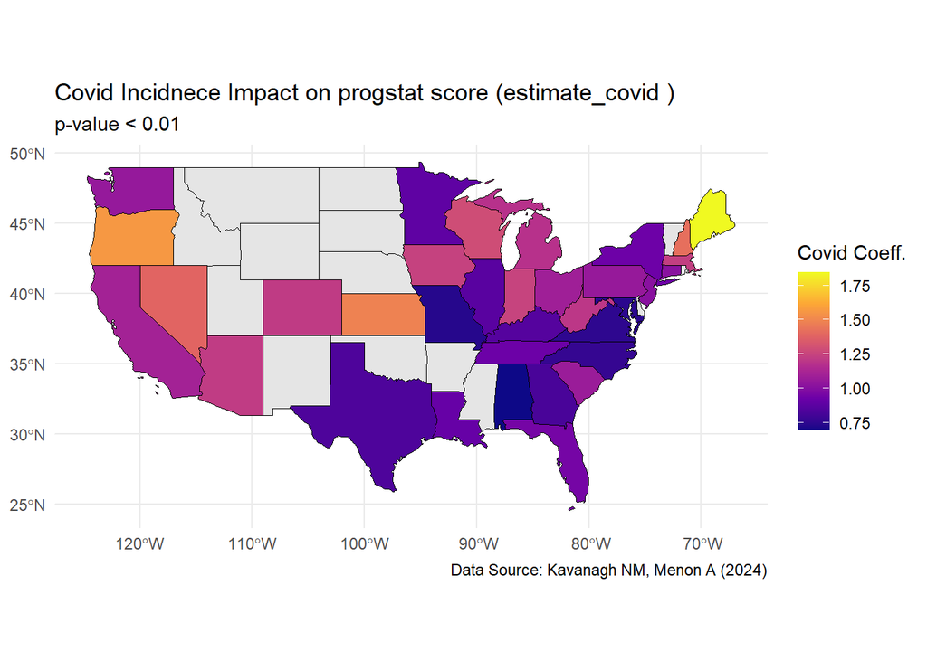

```r
# Load US states gemotry data from spData package and merge witrh our results
us_states <- spData::us_states
merged_data <- us_states %>%
  left_join(all_state_results, by = c("NAME" = "location"))

library(ggplot2)

# Plot
ggplot(data = merged_data) +
  geom_sf(aes(fill = ifelse(p_value_covid < 0.01, estimate_covid, NA)), color = "black") +
  scale_fill_viridis_c(option = "C", na.value = "gray90", name = "Covid Coeff.") +
  labs(
    title = "Covid Incidnece Impact on progstat score (estimate_covid ) ",
    subtitle = "p-value < 0.01",
    caption = "Data Source: Kavanagh NM, Menon A (2024)"
  ) +
  theme_minimal()
```

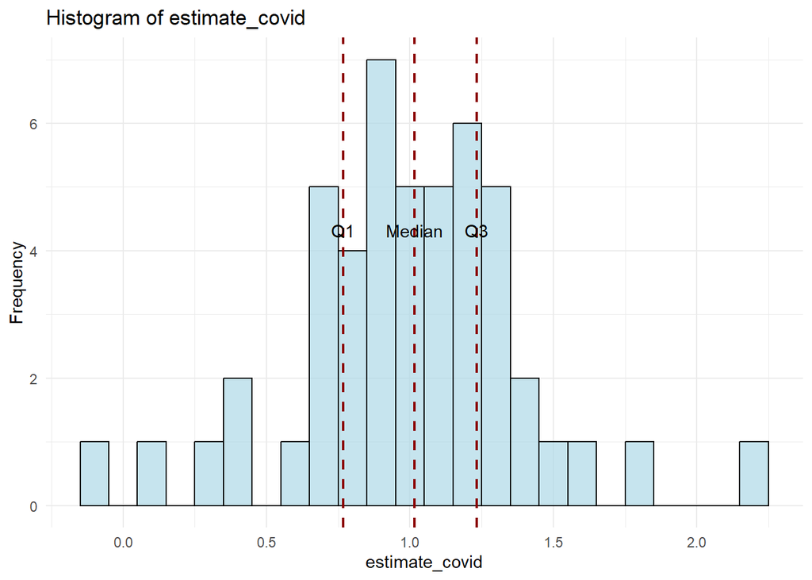

```r
# Alternatively we can also check the summary statistics
covid_stats <- summary(merged_data$estimate_covid, na.rm = TRUE)

median_covid <- covid_stats["Median"]
q1_covid <- covid_stats["1st Qu."]
q3_covid <- covid_stats["3rd Qu."]

# Plot histogram with annotations
ggplot(data = merged_data, aes(x = estimate_covid)) +
  geom_histogram(binwidth = 0.1, fill = "lightblue", color = "black", alpha = 0.7) +
  geom_vline(aes(xintercept = median_covid), linetype = "dashed", color = "darkred", size = 0.8, show.legend = FALSE) +
  geom_vline(aes(xintercept = q1_covid), linetype = "dashed", color = "darkred", size = 0.8, show.legend = FALSE) +
  geom_vline(aes(xintercept = q3_covid), linetype = "dashed", color = "darkred", size = 0.8, show.legend = FALSE) +
  annotate("text", x = median_covid, y = Inf, label = "Median", vjust = 15, color = "black") +
  annotate("text", x = q1_covid, y = Inf, label = "Q1", vjust = 15, color = "black") +
  annotate("text", x = q3_covid, y = Inf, label = "Q3", vjust = 15, color = "black") +
  labs(
    title = "Histogram of estimate_covid",
    x = "estimate_covid",
    y = "Frequency"
  ) +
  theme_minimal()
```

### **Section 3: This section focuses on the cluster map. Here, we demonstrate the workflow for utilizing `listw`**, **`Spdeplisa`**, **`cluster_map`** **. We calculate the average `progstat` scores for each state and identify states that appear to form spatial clusters (though it’s important to note that this is not an entirely accurate representation).**

```r
# step 1 for clutering we need a) a shape file path b) a state/region level summary (progstat_avg  variable in our case)

# Aggregate progstat by state to calculate the average score
aggregated_data <- ces_data_loaded %>%
  group_by(inputstate) %>%
  summarise(progstat_avg = mean(progstat, na.rm = TRUE)) %>%
  ungroup()

filtered_states <- us_states %>%
  left_join(aggregated_data, by = c("NAME" = "inputstate")) %>%
  filter(!is.na(progstat_avg))

# Define a shapefile path
shapefile_path <- tempfile(fileext = ".shp")
sf::st_write(us_states, shapefile_path, quiet = TRUE)
#The tempfile function generates a unique file name in the system's temporary directory.
#But in practice please just take the file from the local drive
# The boave two steps are not needed if one has a local .shp file
# However, 'shapefile_path' is a parameter that has to be defined for the functions to run!!

# Step 2: run listw and spedeplisa
us_states_listw <- DHSr::listw(
  shapefile_path = shapefile_path,
  data = filtered_states %>% st_drop_geometry(),
  loc_shape = "GEOID", # state ID
  loc_data = "GEOID",
  weight_function = function(d) exp(-d / 0.2) # any decaying function of distance
)
```

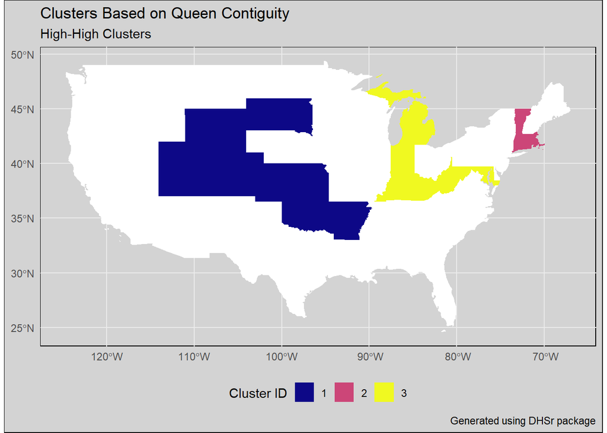

```r
# Step 3 " Apply Spdeplisa function with the average progstat
lisa_result <- DHSr::Spdeplisa(
  data = filtered_states,
  variable_name = "progstat_avg",
  listw = us_states_listw
)

# Step 3  Add LISA labels
lisa_result <- lisa_result %>%
  mutate(lisa_label = case_when(
    lisa_I > 0 ~ "High-High",
    lisa_I < 0 ~ "Low-Low",
    TRUE ~ "Others"
  ))

# Step 4 : run cluster_map}

cluster_map_result <- DHSr::cluster_map(
  dataset = lisa_result,
  lisa_value = "lisa_I",
  lisa_label = "lisa_label",
  label = "High-High",
  lisa_cutoff = 0,
  location_var = "GEOID",
  location_name = "NAME",
  id_start = 1,
  comparison = ">",
  min_area = 0,
  min_ = 3,  # Reduced for smaller demonstration
  title = "Clusters Based on Queen Contiguity",
  subtitle = "High-High Clusters",
  footnote = "Generated using DHSr package",
  legend_position = "bottom",
  color_scheme = "C"
)


# Plot the clusters
print(cluster_map_result$plot)
```

```r
# additionally one may want to see the backend  files for the map :
#head(cluster_map_result$dataset_with_clusters)
#view(cluster_map_result$summary_clusters)
```

# In summary, we conducted 51 regressions, processed and organized the results for seamless visualization, and created a spatial cluster map.

(and the entire piece was just about 12 lines of code! : ) )

**Please Note:** We kept the model straightforward by not including any interaction or any random effect. However, these can easily be incorporated by using the other repeated regression functions (`Replmre2` for random effect and `Repglmre2` for generalized models.) We’ll explore additional functionalities in the future—stay tuned!